# DOT-USD

## DOT-USD today is +0200, 2025-11-02, 03:46:17

This crypto forecast was generated by gemini-2.0-flash API

## Daily Chart

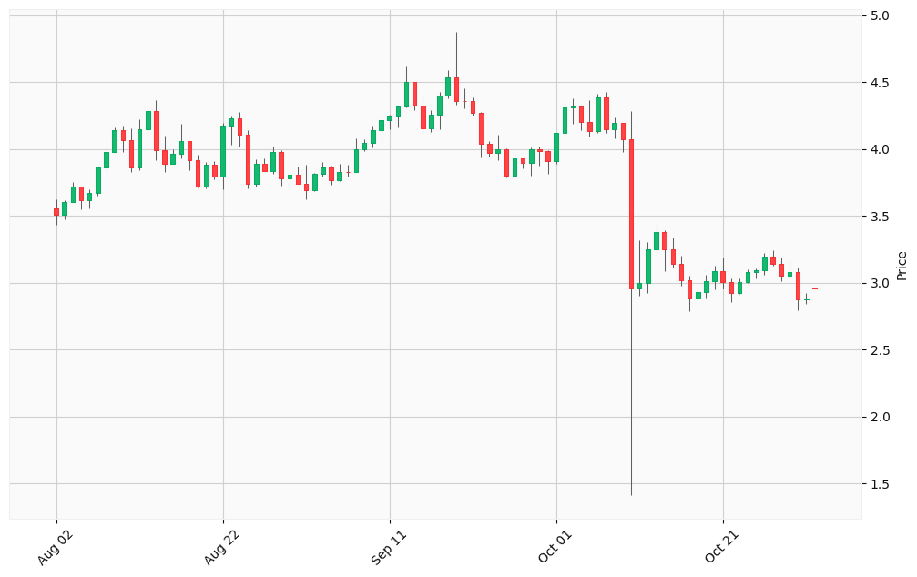

## Hourly Chart

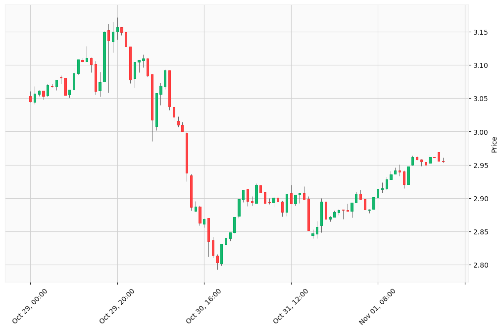

Okay, I will analyze the provided DOT-USD charts (daily for three months and hourly for five days) and generate buy/sell trading signals based on the specified steps. I will use technical analysis on the provided data, simulate news and economic analysis, and provide signals in the requested structured format.

First, I will generate some search queries to collect recent information on DOT-USD.

- **Recent News:** Polkadot is integrating with Ethereum Virtual Machine (EVM) and launching its native Polkadot Virtual Machine (PVM) in December 2025 which is seen as a bullish sign as it can encourage more Ethereum developers to migrate to Polkadot. Telecom integration via Unity Nodes is live. Coinbase Prime is adding Polkadot to its institutional staking suite. Gavin Wood, co-founder of Ethereum and founder of Polkadot, is speaking at sub0 Symbiosis in Buenos Aires on November 14, 2025.
- **Price Prediction:** Mixed signals. One source predicts short-term gains but longer-term decline. Another source suggests a potential rise to $15, with optimistic scenarios reaching $20-25. Some analysts predict DOT could reach $100 to $200 by 2025, contingent on market conditions and technological advancements.
- **Technical Analysis:** Current market sentiment is bearish. A recent surge from $3.88 to $4.11 was noted.
- **Current Price:** Around $2.90 - $3.01.
- **Market Sentiment:** Fear.

Now I will perform technical analysis on the provided data to generate trading signals.

**1. Technical Analysis (Daily Chart - Last Three Months):**

To perform a basic technical analysis, I will calculate a few indicators: